# Exploratory Analysis

## Aviation Crashes from 1908 to 2023

### Authors

Andy Ma, Noah Karst, Josephine Yen, JJ Cai

### Date: 2-20-2023

Winter 2023

### Abstract

Our main question is what are the common trends in aircraft crashes and what preventative measures could be put in place to prevent them, this is important because, even though aircraft crashes are rare, the times they do occur have high fatality rates. To answer this question we will look at different trends in aircraft crashes and determine common ones, then we will look at how they can be prevented. One concern is with the dataset itself as it is from 1908 to the present, leaving room for confounding factors like aircraft models that are no longer used, and to address this, we will tidy up the data and determine a proper cutoff point in which the information is relevant to the questions we are asking.

### Keywords

Keywords: Airplane Crashes; Historical Data; Trends.

### Introduction

In our project, we are looking at the historical trends of airplane crashes from 1908 to present day. The goal for our project is to look for different trends and patterns in aircraft crashes and to see if there are any common themes between those patterns. Once those patterns are established, we want to take a deeper look and see if there are any preventative measures that could combat these trends.

In order to do so, we are looking to answer a few different questions. The first question we are looking to answer is: What year or timeframe had the most amount of fatalitites from aircraft crashes? The second question is: What type and make of aircraft has the most recorded crashes? The third question that we are researching is: Where do aircraft crash the most location wise?

The motivation behind these questions are simple, these questions are asked in order to further establish trends in which we can examine them further and potentially determine preventative measures and increase knowledge on aircraft crashes. With how long the timeframe of the data spans, we wanted to narrow down the questions to provide the most relevant data for us to examine. We determined that these questions were important because of how they interacted with each other and the roles they play in aircraft crashes.

### Related Work

By examining our dataset we will be able to answer our research questions as listed, and learn much more. In using a public dataset we can assume that others have done the same; filtered, extracted, and examined the data to answer questions of their own. Taking a look at related works we found a website “airsafe.com,” intended to inform the general public about airline safety and aircraft fatality statistics (2021). The website has a ranking of airline models fatality rates meaning the statistics included on the site are only crashes that resulted in a death which we thought was interesting.

Another work we decided to look at was an Injury Attorney Firm page. The firm: “AI” has a list ranking the most common causes of Aviation accidents, a list we may confirm through examining our selected dataset (n.d.). It is compelling to see who this data affects. As researchers it is important to think about who may see the end results to our research questions.

Please see the end of the proposal for references page of citations.

### Implications

There are already some implications that can go into why an airplane can crash. Research has shown that 49% of plane crashes occur when descending and landing (Tang, 2020). But we can also assume that most of the crashes can be also caused by human error. Human error can be found in the makes of the aircraft, the procedures that were done incorrectly, or just in general a stroke of bad luck to cause some malfunctioning error. This can be seen from technologists that the radar altimeters from the airplanes can be affected by the 5G signal emitted which is being produced from the network towers. Also, this can be one answer as to why some crashes happen due to the signals being disturbed causing the pilot to be unable to grasp where they are landing. The implications for designers is that they can determine design errors within various aircraft models, maybe mistakes within calculations and structural design issues that are not safe. Policymakers might create stronger policies that surround the decisions of how airplanes are designed, research into aircraft safety, and testing procedures before releasing them to the public for travel.

### Limitations & Challenges

There will be some challenges that will arise within our project idea that will need to be addressed more broadly. The dataset might not be able to achieve an evidence-based and high-level researched strategy in reducing airplane crashes. Being able to create an informative data project in under five weeks and having it create a strong impact on a global scale will be difficult. The project will only scratch the surface in finding trends of airplane crashes. Another limitation is the fact that we do not know how the aircraft models have been updated in the following years or precise changes aircraft companies made within their planes. This means that it will be hard to find trends in any improvements between old and new aircrafts in order to add to our aircraft trends analysis. Further, the identification of the causes of the aircraft crashes may not be accurate or have multiple causes such as manufacturing defects paired with turbulent weather conditions. Thus, our data analysis in our project in specific causes could be limited in not understanding the entire scope of an aircraft crash.

### Summary Information

From the summary findings, we were able to determine five different factors. We were able to determine that there have been 5268 crashes since 1908. After that, we were able to determine that the maximum fatalities that occurred in a crash was 583 fatalities. We also deteremined the average fatality per crash is 20 people, the fatality rate of these crashes is 72.97%. Finally, there were 2477 unique airplane operators.

### Table

| Type | Fatalities |
| --- | --- |
| Boeing B-747-121 / Boeing B-747-206B | 583 |
| Boeing B-747-SR46 | 520 |
| Boeing B-747-168B / Ilyushin IL-76TD | 349 |
| McDonnell Douglas DC-10-10 | 346 |
| Boeing B-747-237B | 329 |
| Lockheed 1011-200 TriStar | 301 |
| Airbus A300B2-203 | 290 |
| Ilyushin Il-76MD | 275 |
| McDonnell Douglas DC-10-10 | 271 |
| Boeing B-747-230B | 269 |

We included this table because we wanted to find the ten most fatal aircraft crashes. Then, from there, we wanted to find the aircrafts that they occured in. I chose this specifically because I wanted to build upon information from our second chart while also approaching it from a different perspective. From this, we can see that variations of the Boeing B-747 make up the top three most fatal crashes. We can also see that of the 10 most fatal crashes, variations of the Boeing B-747 make up 5 of them. I think the information revealed here is interesting because the information in Chart 2 shows that the Douglas DC-3 resulted in the most deaths. Yet the Douglas DC-3 isn’t within the top 10 most fatal crashes.

### Chart 1

Total fatalities from year 1908 to 2009

I chose to present this chart because I wanted to look at the data of total fatalities from all the years the dataset provides. See which year had the highest fatality rate.

I found out that the highest fatalities during this timeframe was during 1972. Total fatality count of 2937.

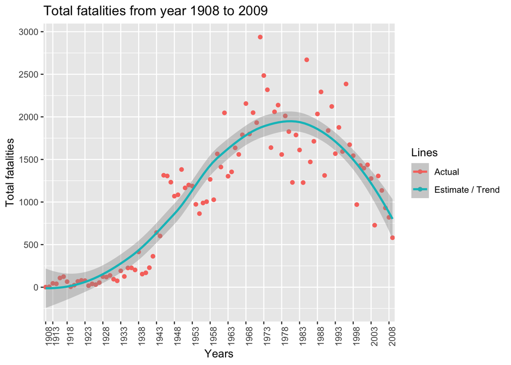

### Chart 2

Top 20 Aircraft Makes with the most Deaths & Top 20 Aircraft Types with the most Deaths

I chose to put together these charts because I thought that it would be interesting to see what aircraft Makes resulted in the most deaths, as well as which specific make resulted in the most deaths.

I was able to find that Boeing has the most deaths of all Aircraft makes. Though the Aircraft type resulting in the most deaths the Douglas DC-3, is not produced by Boeing… which I found particularly interesting.

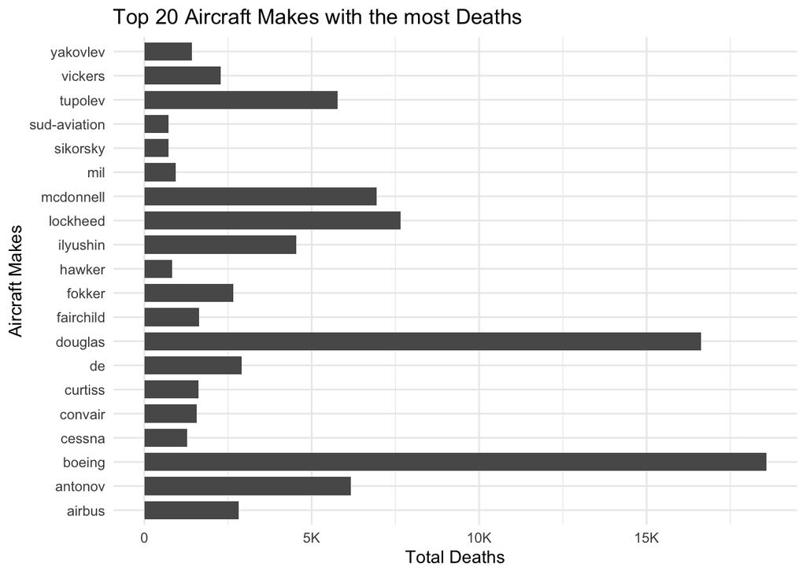

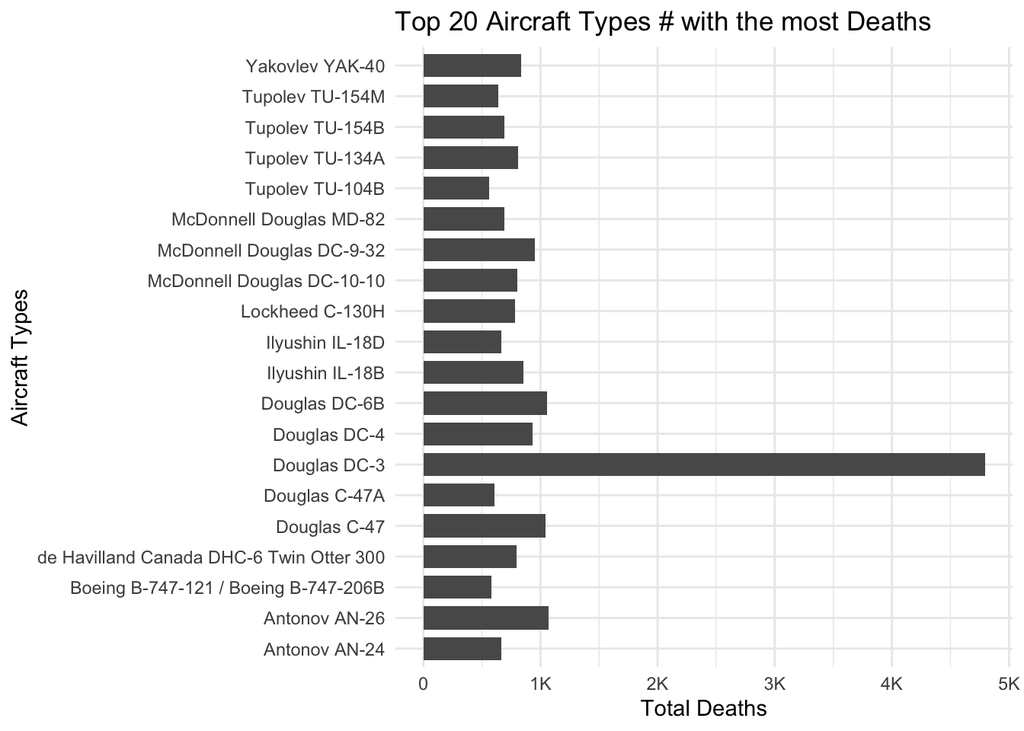

### Chart 3

Top 40 Countries of Aviation Crashes Based on Frequency

I chose to put together this treemap because I thought it would be fascinating to look at the various locations that had the most frequent aviation crashses.

I was able to find that the United States had the greatest freuqency for the country where crashes occured. I had to narrow down the data to look at the top 40 countries because fitting around a hundred countries within the treemap would be too cramped with data and hard to view from the audience’s perspective.

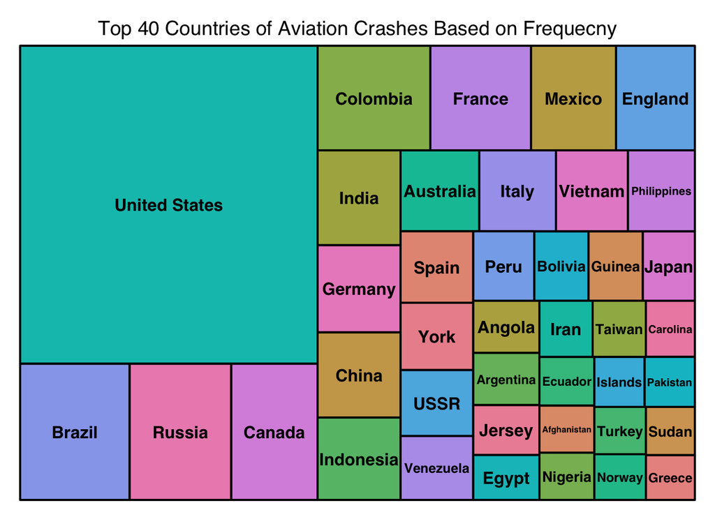

### Refrences

AirSafe LLC. (2021, January 13). Plane Crash Rates By Model. AirSafe. Retrieved February 3, 2023, from http://www.airsafe.com/events/models/rate_mod.htm Houston Personal Injury Attorney. (n.d.). Most Common Causes of Aviation Crashes. Arnold & Itkin Trial Lawyers. Retrieved February 3, 2023, from https://www.arnolditkin.com/blog/injury/most-common-causes-of-aviation-accidents/ National Safety Council. (2022, August 1). Home & Community Safety: Airplane crashes. Injury Facts NSC. Retrieved February 3, 2023, from https://injuryfacts.nsc.org/home-and-community/safety-topics/airplane-crashes/ Tang, A. (2020, October 31). Why airplane takeoffs and landings are so dangerous. Retrieved February 3, 2023, from https://www.businessinsider.com/why-airplane-takeoff-landing-are-dangerous-flight-2019-12